# Medical Distribution Business Analysis Report (Excluding Pharmaceuticals)

Hospital Consumption Data Analysis - 13 Month Study (Non-Pharma Focus)

Medical Distribution Business Analysis

2025-06-07

# 1 Executive Summary

**Current Filter:** Filtered to categories (excluding Pharmaceuticals): Anaesthesia, Cardiology, Dermatology, Gastroenterology, General/Consumables, Miscellaneous, Ortho, Radiology, Respiratory, Surgical, Urology, Wound Care  
**Available Categories (in original dataset):** Anaesthesia, Cardiology, Dermatology, Gastroenterology, General/Consumables, Miscellaneous, Ortho, Pharmaceuticals, Radiology, Respiratory, Surgical, Urology, Wound Care

## 1.1 Key Performance Indicators

304,056

Total Units Consumed (Non-Pharma)

1007

Unique Products (Non-Pharma)

66

Current Vendors (Non-Pharma)

13

Months of Data

## 1.2 Strategic Recommendations

**Longer-Term Strategy (Non-Pharma Focus):**

- **Market Expansion:** Grow market share in high-potential non-pharmaceutical categories.
- **Inventory Optimization:** Fine-tune stock levels for key non-pharmaceutical products.

# 2 Market Analysis (Excluding Pharmaceuticals)

## 2.1 ABC Classification Analysis

### 2.1.1 What is ABC Analysis?

ABC analysis is an inventory categorization technique that classifies items based on their consumption value. This helps prioritize management efforts:

- **Class A (High Priority):** Items representing approximately **80% of consumption volume** but only **20% of total items**. These require tight control, accurate forecasting, and secure supplier relationships.
- **Class B (Medium Priority):** Items representing approximately **15% of consumption volume** and **30% of items**. These require moderate control with periodic reviews and standard ordering procedures.
- **Class C (Low Priority):** Items representing only **5% of consumption volume** but **50% of total items**. These can be managed with simple controls, bulk ordering, or just-in-time delivery.

**Benefits:**

- 💰 **Cost Savings:** Reduced inventory holding costs
- 📈 **Improved Service:** Better availability of critical items
- ⚡ **Efficient Operations:** Different management strategies for different item classes

ABC Analysis Summary - All Non-Pharmaceutical Categories

| ABC_Class | Number_of_Items | Percentage_of_Items | Total_Volume | Percentage_of_Volume |
| --- | --- | --- | --- | --- |
| A | 37 | 3.67428 | 241,890 | 79.554424 |
| B | 120 | 11.91658 | 46,905 | 15.426435 |
| C | 850 | 84.40914 | 15,261 | 5.019141 |

### 2.1.2 Top 20 High-Priority Items (Class A - Non-Pharma)

| ITEM_NAME | CATEGORY | Total_Quantity | Transaction_Count | Percentage_of_Total |
| --- | --- | --- | --- | --- |
| EXAMINATION GLOVES | Surgical | 81,393 | 13 | 26.77 |
| POCT GLUCOSPOT STRIPS | Radiology | 23,000 | 7 | 7.56 |
| POCT LANCET ROUND | Radiology | 21,040 | 8 | 6.92 |
| PARAID-650 | Miscellaneous | 11,250 | 7 | 3.7 |
| ECG ELECTRODES | Radiology | 8,161 | 9 | 2.68 |
| CALCEL -D3 | Miscellaneous | 7,350 | 6 | 2.42 |
| RAPPIN-DSR CAPS | Ortho | 6,200 | 6 | 2.04 |
| DISPOVAN NEEDLE 18 G | General/Consumables | 5,700 | 10 | 1.87 |
| T3-LC | Miscellaneous | 3,940 | 2 | 1.3 |
| MEDIGRIP IV FIX | Miscellaneous | 3,929 | 8 | 1.29 |

[output cut: 10 more lines]

**Note:** These are the top 20 Class A items based on the current filter (excluding Pharmaceuticals). They represent the most significant products by volume in the selected non-pharmaceutical categories.

### 2.1.3 ABC Analysis Visualization

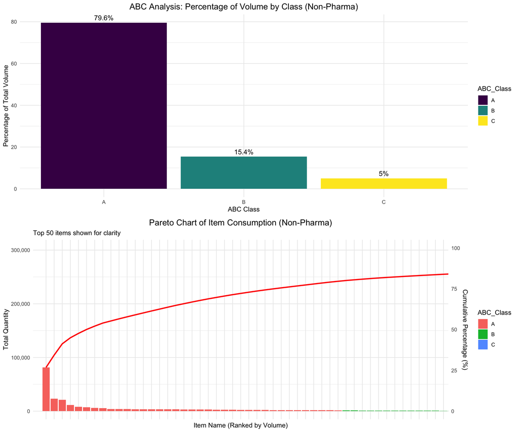

## 2.2 ABC Analysis Summary & Strategic Implications

#### 🎯 ABC Analysis Key Findings (Non-Pharma)

- **Class A items:** Represent **79.6%** of total non-pharmaceutical consumption volume from just **3.7%** of unique non-pharmaceutical items.
- **Top Item:** The single highest volume non-pharmaceutical item, **EXAMINATION GLOVES**, accounts for **81,393** units (26.77% of total non-pharma volume).
- **Focus Area:** Concentrating efforts on Class A non-pharmaceutical items offers the highest return on investment for inventory management and supplier negotiation.

**Operational Recommendations:**

- **Class A:** Daily monitoring, safety stock, multiple suppliers, premium service
- **Class B:** Weekly reviews, standard inventory policies, regular supplier relationships
- **Class C:** Monthly/quarterly reviews, bulk ordering, consider dropshipping

# 3 Category Performance Analysis

[output not shown]

| CATEGORY | Total_Transactions | Total_Quantity | Unique_Items | Unique_Vendors | Avg_Transaction_Size | Percentage_of_Total | Market_Priority |
| --- | --- | --- | --- | --- | --- | --- | --- |
| Miscellaneous | 1142 | 111,132 | 531 | 52 | 97.3 | 36.5% | High Priority |
| Surgical | 107 | 91,581 | 39 | 10 | 855.9 | 30.1% | High Priority |
| Radiology | 78 | 57,555 | 31 | 10 | 737.9 | 18.9% | Medium Priority |
| Ortho | 278 | 12,990 | 181 | 19 | 46.7 | 4.3% | Low Priority |
| General/Consumables | 95 | 12,609 | 28 | 8 | 132.7 | 4.1% | Low Priority |
| Dermatology | 137 | 7,917 | 66 | 12 | 57.8 | 2.6% | Low Priority |
| Respiratory | 94 | 4,127 | 24 | 8 | 43.9 | 1.4% | Low Priority |
| Wound Care | 47 | 3,333 | 18 | 4 | 70.9 | 1.1% | Low Priority |
| Urology | 64 | 2,154 | 24 | 5 | 33.7 | 0.7% | Low Priority |
| Gastroenterology | 19 | 483 | 8 | 7 | 25.4 | 0.2% | Low Priority |

[output cut: 2 more lines]

**🔍 Category Filtering Options:**  
This report is pre-filtered to exclude ‘Pharmaceuticals’. To analyze other specific non-pharmaceutical categories, you can modify the `selected_categories` variable at the top of the report further, for example:

```
selected_categories <-
available_categories[!available_categories %in% c(“Pharmaceuticals”,
“AnotherCategoryToExclude”)]
```

*Current filter: All Non-Pharmaceutical Categories Shown*

## 3.1 Category Distribution Visualization

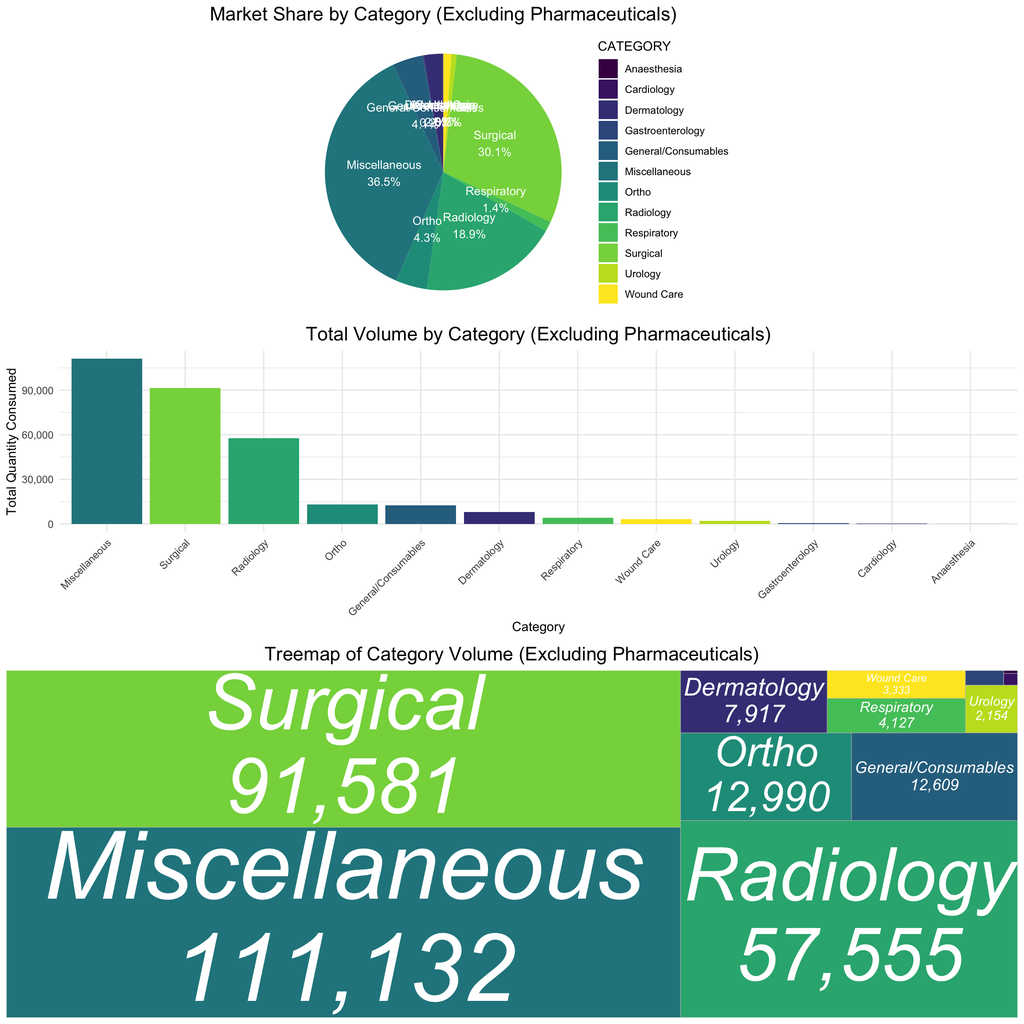

# 4 Vendor Analysis (Excluding Pharmaceuticals)

[output not shown]

| VENDOR | Total_Transactions | Total_Quantity | Unique_Items_Supplied | Avg_Transaction_Size | Percentage_of_Total_Volume | Vendor_Tier |
| --- | --- | --- | --- | --- | --- | --- |
| R&amp;R SURGICALS | 838 | 181,761.0 | 342 | 216.9 | 59.8% | Tier 1 (Key Supplier) |
| V K MEDICALS | 95 | 52,482.0 | 38 | 552.4 | 17.3% | Tier 1 (Key Supplier) |
| LAALITHYAM HOSPITALS PVT LTD | 255 | 24,539.0 | 167 | 96.2 | 8.1% | Tier 2 (Regular Supplier) |
| KRISHNA PHARMACEUTICAL DISTRIBUTORS | 282 | 11,440.5 | 138 | 40.6 | 3.8% | Tier 2 (Regular Supplier) |
| SUMAN AGENCIES HYD PRIVATE LIMITED | 44 | 8,651.5 | 35 | 196.6 | 2.8% | Tier 2 (Regular Supplier) |
| ARKAS PHARMA PRIVATE LIMITED | 10 | 3,800.0 | 7 | 380 | 1.2% | Tier 2 (Regular Supplier) |
| DELIGHT BIO PHARMA PVT LTD | 8 | 3,580.0 | 6 | 447.5 | 1.2% | Tier 2 (Regular Supplier) |
| HEALTH PHARMA | 95 | 3,028.0 | 51 | 31.9 | 1% | Tier 3 (Occasional Supplier) |
| KUMAR MEDINEEDS | 8 | 2,836.0 | 2 | 354.5 | 0.9% | Tier 3 (Occasional Supplier) |
| SS PHARMA | 2 | 2,700.0 | 2 | 1350 | 0.9% | Tier 3 (Occasional Supplier) |

[output cut: 10 more lines]

**Vendor Consolidation Opportunity:** Analyze Tier 3 vendors (supplying <1% of total volume) for potential consolidation to streamline procurement and potentially negotiate better terms with Tier 1 or Tier 2 suppliers.

## 4.1 Vendor Distribution Visualization

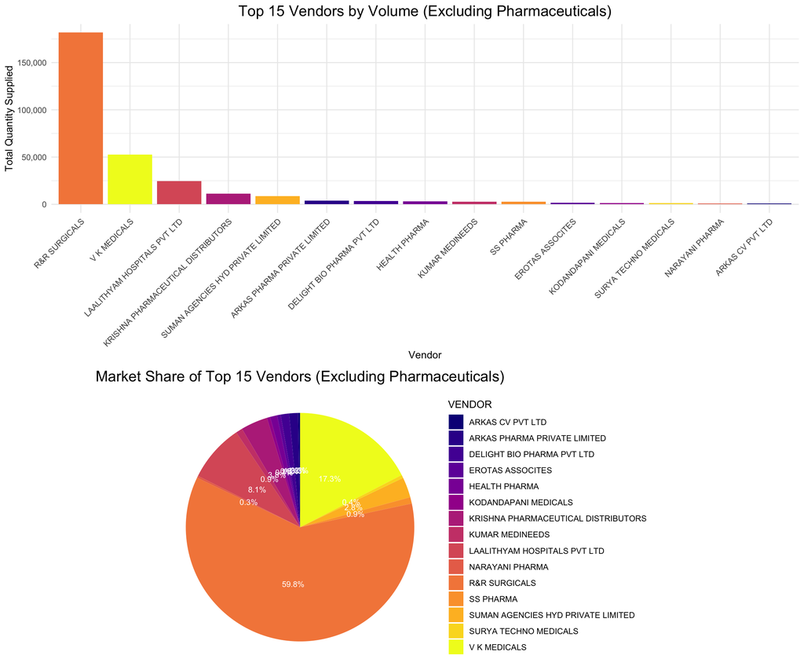

# 5 Time Series Analysis (Excluding Pharmaceuticals)

[output not shown]

| Month_Year | Total_Quantity | Moving_Avg_3M | Growth_Rate |
| --- | --- | --- | --- |
| 2024-05 | 28,910.0 | N/A | N/A |
| 2024-06 | 11,689.0 | N/A | -59.6% |
| 2024-07 | 35,366.0 | 25,322 | 202.6% |
| 2024-08 | 25,662.0 | 24,239 | -27.4% |
| 2024-09 | 32,193.0 | 31,074 | 25.5% |
| 2024-10 | 26,169.0 | 28,008 | -18.7% |
| 2024-11 | 13,996.0 | 24,119 | -46.5% |
| 2024-12 | 20,950.5 | 20,372 | 49.7% |
| 2025-01 | 28,479.0 | 21,142 | 35.9% |
| 2025-02 | 21,002.0 | 23,477 | -26.3% |

[output cut: 3 more lines]

## 5.1 Monthly Trend Visualization

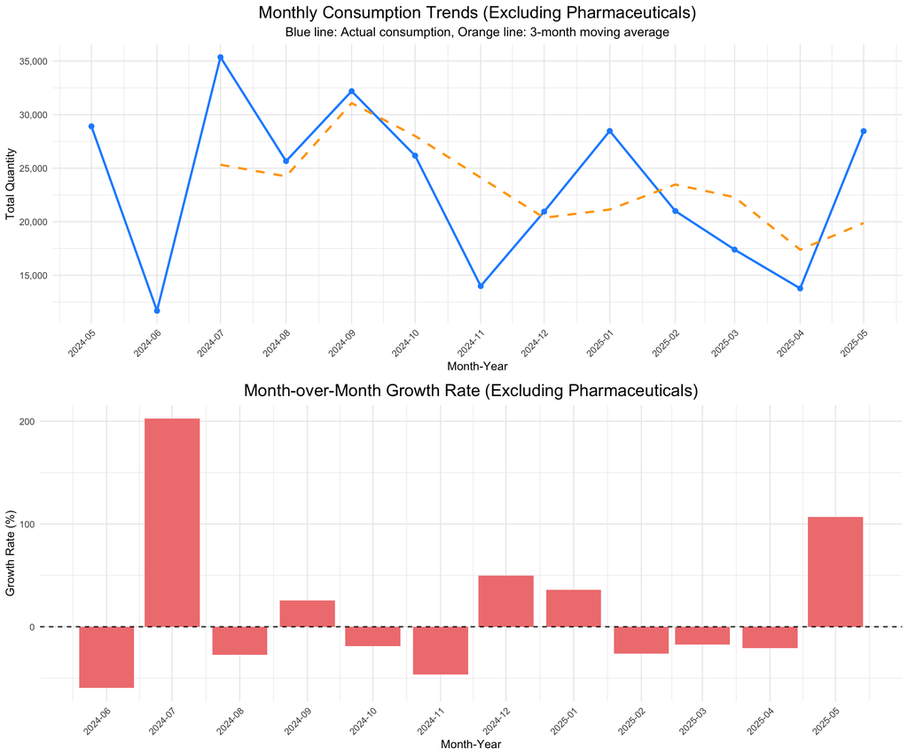

### Report Generated on 2025-06-07

This analysis is based on 13 months of actual hospital consumption data (Excluding Pharmaceuticals)  
Total records analyzed: 2,132  
Data period: 2024-05-01 to 2025-05-01  
**Current filter: Filtered to categories (excluding Pharmaceuticals): Anaesthesia, Cardiology, Dermatology, Gastroenterology, General/Consumables, Miscellaneous, Ortho, Radiology, Respiratory, Surgical, Urology, Wound Care**

#### 🔧 How to Further Filter Categories

This report already excludes ‘Pharmaceuticals’. To further refine the analysis on the remaining categories, modify this line in the data loading section:

```
selected_categories <-
available_categories[!available_categories %in% c(“Pharmaceuticals”,
“CategoryToExclude1”, “CategoryToExclude2”)]
```

**Available non-pharmaceutical categories in this report:**  
“Anaesthesia”, “Cardiology”, “Dermatology”, “Gastroenterology”, “General/Consumables”, “Miscellaneous”, “Ortho”, “Radiology”, “Respiratory”, “Surgical”, “Urology”, “Wound Care”